# Inference in Regression

Katherine Shim

October 29, 2018

### Inference

Standard error of the regression coefficients

- $\sigma_{\hat \beta_1}^2 = Var(\hat \beta_1) = \sigma^2 / \sum_{i=1}^n (X_i - \bar X)^2$
- $\sigma_{\hat \beta_0}^2 = Var(\hat \beta_0) = \left(\frac{1}{n} + \frac{\bar X^2}{\sum_{i=1}^n (X_i - \bar X)^2 }\right)\sigma^2$
- In practice, $\sigma$ is replaced by its estimate, $\hat \sigma^2 = \frac{1}{n-2}\sum_{i=1}^n e_i^2$
- It’s probably not surprising that under iid Gaussian errors
  $$\frac{\hat \beta_j - \beta_j}{\hat \sigma_{\hat \beta_j}}$$
  follows a $t$ distribution with $n-2$ degrees of freedom and a normal distribution for large $n$.
- This can be used to create confidence intervals and perform hypothesis tests.

### Inference coding example

```r
data(diamond)
y <- diamond$price;
x <- diamond$carat;
n <- length(y)
beta1 <- cor(y, x) * sd(y) / sd(x)
beta0 <- mean(y) - beta1 * mean(x)
e <- y - beta0 - beta1 * x
#Estimate of standard deviation around the regression line
sigma <- sqrt(sum(e^2) / (n-2))

#Sums of square of x
ssx <- sum((x - mean(x))^2)
#Standard error of beta0 and beta1
seBeta0 <- (1 / n + mean(x) ^ 2 / ssx) ^ .5 * sigma
seBeta1 <- sigma / sqrt(ssx)
# Two t statistics. Null hypotheses are beta0 and beta1 are equal to zero
tBeta0 <- beta0 / seBeta0; tBeta1 <- beta1 / seBeta1
# Two p-values for each coeffs
pBeta0 <- 2 * pt(abs(tBeta0), df = n - 2, lower.tail = FALSE)
pBeta1 <- 2 * pt(abs(tBeta1), df = n - 2, lower.tail = FALSE)
#Summary table
coefTable <- rbind(c(beta0, seBeta0, tBeta0, pBeta0), c(beta1, seBeta1, tBeta1, pBeta1))
colnames(coefTable) <- c("Estimate", "Std. Error", "t value", "P(>|t|)")
rownames(coefTable) <- c("(Intercept)", "x")
coefTable
```

```
##              Estimate Std. Error   t value      P(>|t|)
## (Intercept) -259.6259   17.31886 -14.99094 2.523271e-19
## x           3721.0249   81.78588  45.49715 6.751260e-40
```

```r
fit <- lm(y~x)
summary(fit)$coefficients
```

```
##              Estimate Std. Error   t value     Pr(>|t|)
## (Intercept) -259.6259   17.31886 -14.99094 2.523271e-19
## x           3721.0249   81.78588  45.49715 6.751260e-40
```

### Inference confidence interval of coefficients

```r
sumCoef <- summary(fit)$coefficients
#CI of intercept
sumCoef[1,1] + c(-1,1)*qt(0.975, df=fit$df)*sumCoef[1,2]
```

```
## [1] -294.4870 -224.7649
```

```r
#CI of slope
sumCoef[2,1] + c(-1,1)*qt(0.975, df=fit$df)*sumCoef[2,2]
```

```
## [1] 3556.398 3885.651
```

The interpretation of CI of slope is “with 95% confidence, we estimate that a 0.1 carat increase in diamond size is going to result in a 356 to 389 increase in price in, in Singapore dollars.

### Prediction of outcomes

- The estimate for prediction at point $x_0$ is
  $$\hat{\beta_0}+\hat{\beta_1}x_0$$
- A standard error is needed to create a prediction interval.
- There’s a distinction between intervals for the regression line at point $x_0$ and the prediction of what a $y$ would be at point $x_0$.
- Line at $x_0$ SE, $\hat \sigma\sqrt{\frac{1}{n} + \frac{(x_0 - \bar X)^2}{\sum_{i=1}^n (X_i - \bar X)^2}}$
- Prediction interval SE at $x_0$, $\hat \sigma\sqrt{1 + \frac{1}{n} + \frac{(x_0 - \bar X)^2}{\sum_{i=1}^n (X_i - \bar X)^2}}$

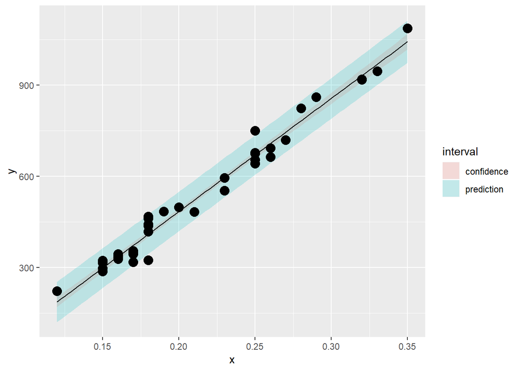

```r
newx = data.frame(x = seq(min(x), max(x), length = 100))
p1 = data.frame(predict(fit, newdata= newx,interval = ("confidence")))
p2 = data.frame(predict(fit, newdata = newx,interval = ("prediction")))
p1$interval = "confidence"
p2$interval = "prediction"
p1$x = newx$x
p2$x = newx$x
dat = rbind(p1, p2)
names(dat)[1] = "y"
g <- ggplot(dat, aes(x = x, y = y))
g <- g + geom_ribbon(aes(ymin = lwr, ymax = upr, fill = interval), alpha = 0.2)
g <- g + geom_line()
g <- g + geom_point(data = data.frame(x = x, y=y), aes(x = x, y = y), size = 4)
g
```

As plot demonstrates, prediction interval is always larger than confidence interval. Also both of the intervals get narrower toward the center of the data cloud and then get wider as they head out to the tails. We are more confident in our predictions, when the predictor variable is closer to the mean of the X’s